# ISLR_Ch_7

Austin Pesina

4/23/2021

## Problem 6

In this exercise, you will further analyze the [Wage](https://rdrr.io/cran/ISLR/man/Wage.html) data set considered throughout this chapter.

**(a) Perform polynomial regression to predict `wage` using `age`. Use cross-validation to select the optimal degree $d$ for the polynomial. What degree was chosen, and how does this compare to the results of hypothesis testing using ANOVA? Make a plot of the resulting polynomial fit to the data.**

```r
attach(Wage)
set.seed(1)
cv.error <- rep(0,5)

for (i in 1:5){
glm.fit <- glm(wage ~ poly(age,i),data=Wage)
cv.error[i]<- cv.glm(Wage,glm.fit,K=10)$delta[1]
}
cv.error
```

```
## [1] 1676.826 1600.763 1598.399 1595.651 1594.977
```

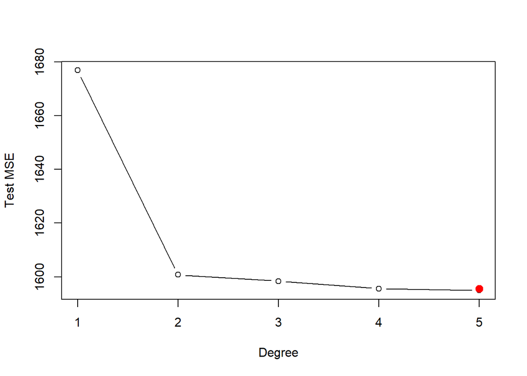

```r
plot(cv.error, type="b", xlab="Degree", ylab="Test MSE")
points(which.min(cv.error), cv.error[4], col="red", pch=20, cex=2)
```

The optimal degree via cross-validation is 5.

```r
fit_1 <- lm(wage ~ age, data=Wage)
fit_2 <- lm(wage ~ poly(age, 2), data=Wage)
fit_3 <- lm(wage ~ poly(age, 3), data=Wage)
fit_4 <- lm(wage ~ poly(age, 4), data=Wage)
fit_5 <- lm(wage ~ poly(age, 5), data=Wage)
anova(fit_1, fit_2, fit_3, fit_4, fit_5)
```

```
## Analysis of Variance Table
##
## Model 1: wage ~ age
## Model 2: wage ~ poly(age, 2)
## Model 3: wage ~ poly(age, 3)
## Model 4: wage ~ poly(age, 4)
## Model 5: wage ~ poly(age, 5)
##   Res.Df     RSS Df Sum of Sq        F    Pr(>F)
## 1   2998 5022216
## 2   2997 4793430  1    228786 143.5931 < 2.2e-16 ***
## 3   2996 4777674  1     15756   9.8888  0.001679 **
## 4   2995 4771604  1      6070   3.8098  0.051046 .
## 5   2994 4770322  1      1283   0.8050  0.369682
## ---
## Signif. codes:  0 '***' 0.001 '**' 0.01 '*' 0.05 '.' 0.1 ' ' 1
```

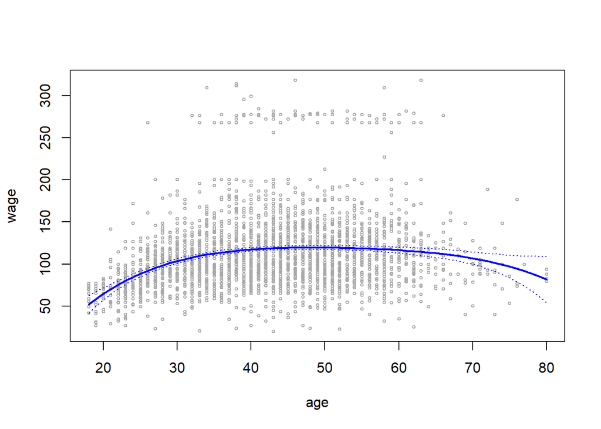

```r
age_lim <- range(age)
age_grid <- seq(from=age_lim[1], to=age_lim[2])
preds <- predict(fit_4, newdata=list(age=age_grid),se=TRUE)
se_bands <- cbind(preds$fit+2*preds$se.fit,preds$fit-2*preds$se.fit)

plot(age, wage, xlim=age_lim, cex=.5, col="darkgrey")
lines(age_grid, preds$fit, lwd=2, col="blue")
matlines(age_grid, se_bands, lwd=1, col="blue", lty=3)
```

**(b) Fit a step function to predict `wage` using `age`, and perform cross-validation to choose the optimal number of cuts. Make a plot of the fit obtained.**

```r
set.seed(2)

cv.errors <- rep(NA, 10)

for(i in 2:10){
  Wage$age.cut <- cut(Wage$age,i)
  glm.fit <- glm(wage ~ age.cut, data=Wage)
  cv.errors[i] <- cv.glm(Wage, glm.fit, K=10)$delta[1]
}

cv.errors
```

```
##  [1]       NA 1734.448 1681.623 1635.869 1632.864 1621.643 1613.148 1601.850
##  [9] 1610.852 1603.607
```

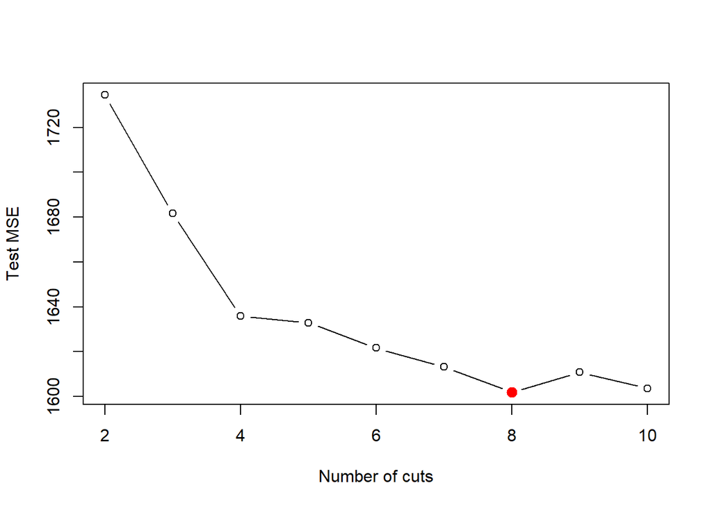

```r
plot(2:10, cv.errors[-1], type="b", xlab="Number of cuts", ylab="Test MSE")
points(which.min(cv.errors), cv.errors[which.min(cv.errors)], col="red", pch=20, cex=2)
```

The optimal number of cuts is 8.

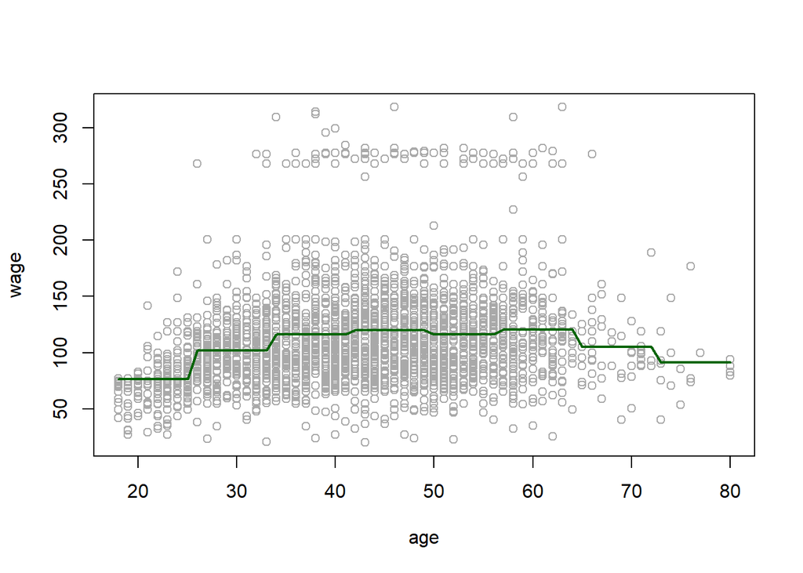

```r
fit_step <- glm(wage ~ cut(age, 8), data=Wage)
preds <- predict(fit_step, data.frame(age = age_grid))
plot(age, wage, col="darkgray")
lines(age_grid, preds, col="darkgreen", lwd=2)
```

## Problem 10

This question relates to the [College](https://rdrr.io/cran/ISLR/man/College.html) data set.

```r
attach(College)
```

**(a) Split the data into a training set and a test set. Using out-of-state tuition as the response and the other variables as the predictors, perform forward step-wise selection on the training set in order to identify a satisfactory model that uses just a subset of the predictors.**

```r
set.seed(10)
test_sample <- sample(1:nrow(College), nrow(College)/4)
train <- College[-test_sample, ]
test <- College[test_sample, ]



fwd <- regsubsets(Outstate ~ ., data=train, nvmax=17, method='forward')
fwd_sum <- summary(fwd)

par(mfrow=c(2,2))
plot(fwd_sum$cp ,xlab="Number of Variables ", ylab="Cp",
type="b")
points(which.min(fwd_sum$cp), fwd_sum$cp[which.min(fwd_sum$cp)], col="red", cex=2, pch=20)

plot(fwd_sum$bic ,xlab="Number of Variables ",
ylab="BIC",type="b")
points(which.min(fwd_sum$bic), fwd_sum$bic[which.min(fwd_sum$bic)], col="red", cex=2, pch=20)

plot(fwd_sum$adjr2 ,xlab="Number of Variables ",
ylab="Adjusted R^2^",type="b")
points(which.max(fwd_sum$adjr2), fwd_sum$adjr2[which.max(fwd_sum$adjr2)], col="red", cex=2, pch=20)


which.min(fwd_sum$cp)
```

```
## [1] 14
```

```r
which.min(fwd_sum$bic)
```

```
## [1] 6
```

```r
which.max(fwd_sum$adjr2)
```

```
## [1] 14
```

```r
test_matrix <- model.matrix(Outstate~., data=test)

val.errors <- rep(NA,17)
for(i in 1:17){
 coefi <- coef(fwd,id=i)
 pred <- test_matrix[,names(coefi)]%*%coefi
 val.errors[i] <- mean((test$Outstate-pred)^2)
}

which.min(val.errors)
```

```
## [1] 13
```

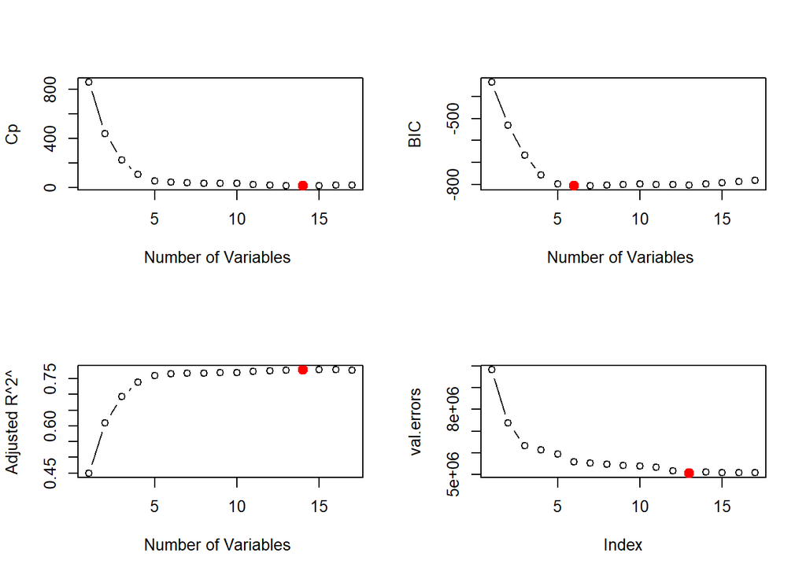

```r
plot(val.errors, type='b')
points(which.min(val.errors), val.errors[13], col='red', pch=20, cex=2)
```

The best model selected with the forward step-wise method has 14 variables but we start seeing a decrease in MSE around 5 variables.

```r
fwd_full <- regsubsets(Outstate ~ ., data=College, nvmax=17, method='forward')
coef(fwd_full, 5)
```

```
##   (Intercept)    PrivateYes    Room.Board           PhD   perc.alumni
## -2864.6325619  2936.7416766     1.0677573    40.5334088    61.3147684
##        Expend
##     0.2253945
```

**(b) Fit a GAM on the training data, using out-of-state tuition as the response and the features selected in the previous step as the predictors. Plot the results, and explain your findings.**

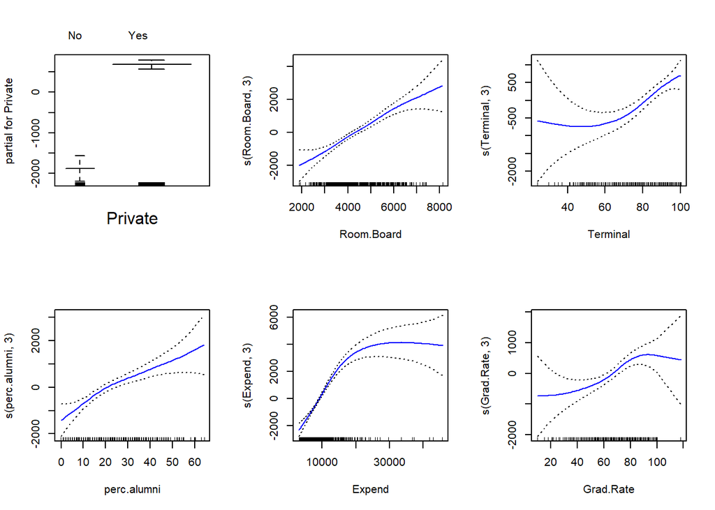

```r
gam_fit <- gam(Outstate ~ Private + s(Room.Board, 3) + s(Terminal, 3) +
                 s(perc.alumni, 3) + s(Expend, 3) + s(Grad.Rate, 3), data=train)

par(mfrow=c(2,3))
plot(gam_fit, se=TRUE, col="blue")
```

**(c) Evaluate the model obtained on the test set, and explain the results obtained.**

```r
preds <- predict(gam_fit, newdata = test)
error <- mean((test$Outstate-preds)^2)

val.errors[5]-error
```

```
## [1] 1521492
```

**(d) FOr which variables, if any, is there evidence of a non-linear relationship with the response?**

```r
summary(gam_fit)
```

```
##
## Call: gam(formula = Outstate ~ Private + s(Room.Board, 3) + s(Terminal,
##     3) + s(perc.alumni, 3) + s(Expend, 3) + s(Grad.Rate, 3),
##     data = train)
## Deviance Residuals:
##      Min       1Q   Median       3Q      Max
## -6739.40 -1164.94    13.13  1251.84  5110.45
##
## (Dispersion Parameter for gaussian family taken to be 3279305)
##
##     Null Deviance: 9052394759 on 582 degrees of freedom
## Residual Deviance: 1856087768 on 566.0004 degrees of freedom
## AIC: 10420.06
##
## Number of Local Scoring Iterations: NA
##
## Anova for Parametric Effects
##                    Df     Sum Sq    Mean Sq F value    Pr(>F)
## Private             1 2531926414 2531926414 772.092 < 2.2e-16 ***
## s(Room.Board, 3)    1 1838032285 1838032285 560.495 < 2.2e-16 ***
## s(Terminal, 3)      1  717299850  717299850 218.735 < 2.2e-16 ***
## s(perc.alumni, 3)   1  468765155  468765155 142.946 < 2.2e-16 ***
## s(Expend, 3)        1  602658177  602658177 183.776 < 2.2e-16 ***
## s(Grad.Rate, 3)     1   56572795   56572795  17.252  3.78e-05 ***
## Residuals         566 1856087768    3279305
## ---
## Signif. codes:  0 '***' 0.001 '**' 0.01 '*' 0.05 '.' 0.1 ' ' 1
##
## Anova for Nonparametric Effects
##                   Npar Df  Npar F     Pr(F)
## (Intercept)
## Private
## s(Room.Board, 3)        2  0.8400   0.43225
## s(Terminal, 3)          2  2.2759   0.10365
## s(perc.alumni, 3)       2  1.4957   0.22497
## s(Expend, 3)            2 30.9350 1.781e-13 ***
## s(Grad.Rate, 3)         2  2.7295   0.06611 .
## ---
## Signif. codes:  0 '***' 0.001 '**' 0.01 '*' 0.05 '.' 0.1 ' ' 1
```